# Somativa_Saude-1

- **Acadêmica:** Francine Estefanela Moura
- **Disciplina:** IA Aplicada à Saúde

## **Análise de Fatores de Risco Cardiovascular com Machine Learning**

### **1. Importando Bibliotecas**

```python
import pandas as pd  # Biblioteca para manipulação de dados em tabelas excel
import numpy as np  # Biblioteca para trabalhar com funções matemáticas
import matplotlib.pyplot as plt  # Biblioteca para criar gráficos e visualizações
import seaborn as sns  # Biblioteca para visualização de dados, com gráficos mais estilizados
sns.set_style()  # Define o estilo dos gráficos do seaborn
%matplotlib inline
from sklearn.model_selection import train_test_split  # Função para dividir dados em treino e teste
from sklearn.linear_model import LogisticRegression  # Modelo de regressão logística para classificação
from sklearn.preprocessing import StandardScaler  # Ferramenta para padronizar/normalizar dados
from sklearn.ensemble import RandomForestClassifier  # Modelo de classificação baseado em árvores
from sklearn.metrics import classification_report, accuracy_score  # Métricas para avaliar o modelo
from sklearn.metrics import confusion_matrix  # Matriz para visualizar acertos e erros de classificação
```

### **2. Importando Datasets**

Carregamos os dataset UCI, que contém informações sobre doenças cardíacas e de mortalidade por doenças cardíacas no Brasil, e as primeiras linhas do dataset UCI para visualização inicial dos dados.

```python
# Importação dos datasets
df_uci = pd.read_csv("https://raw.githubusercontent.com/carlosfab/curso_data_science_na_pratica/master/modulo_03/heart-disease-uci.csv")
df_brasil = pd.read_csv("https://raw.githubusercontent.com/carlosfab/curso_data_science_na_pratica/master/modulo_03/mortes_doencas_cardiovasculares.csv")

# Visualização das primeiras linhas do dataset UCI
print("Primeiras linhas do dataset UCI:")
df_uci.head()
```

```
Primeiras linhas do dataset UCI:
```

|  | age | sex | cp | trestbps | chol | fbs | restecg | thalach | exang | oldpeak | slope | ca | thal | num |
| --- | --- | --- | --- | --- | --- | --- | --- | --- | --- | --- | --- | --- | --- | --- |
| 0 | 63.0 | 1.0 | 1.0 | 145.0 | 233.0 | 1.0 | 2.0 | 150.0 | 0.0 | 2.3 | 3.0 | 0.0 | 6.0 | 0 |
| 1 | 67.0 | 1.0 | 4.0 | 160.0 | 286.0 | 0.0 | 2.0 | 108.0 | 1.0 | 1.5 | 2.0 | 3.0 | 3.0 | 2 |
| 2 | 67.0 | 1.0 | 4.0 | 120.0 | 229.0 | 0.0 | 2.0 | 129.0 | 1.0 | 2.6 | 2.0 | 2.0 | 7.0 | 1 |
| 3 | 37.0 | 1.0 | 3.0 | 130.0 | 250.0 | 0.0 | 0.0 | 187.0 | 0.0 | 3.5 | 3.0 | 0.0 | 3.0 | 0 |
| 4 | 41.0 | 0.0 | 2.0 | 130.0 | 204.0 | 0.0 | 2.0 | 172.0 | 0.0 | 1.4 | 1.0 | 0.0 | 3.0 | 0 |

**Análise:** Descrição das variáveis para melhor entendimento dos atributos.

- **age:** Idade em anos.
- **sex:** Sexo (0: mulher, 1: homem).
- **cp:** Tipo de dor torácica (1-4, onde 1 é angina típica e 4 é assintomática).
- **trestbps:** Pressão arterial em repouso.
- **chol:** Colesterol sérico (mg/dL).
- **fbs:** Açúcar no sangue em jejum > 120mg/dL (0: False, 1: True).
- **restecg:** Resultado do eletrocardiograma de repouso (0-2).
- **thalach:** Frequência cardíaca máxima atingida.
- **exang:** Angina induzida pelo exercício (0: não, 1: sim).
- **oldpeak:** Depressão do segmento ST.
- **slope:** Inclinação do segmento ST no pico do exercício.
- **ca:** Número de vasos principais colorido por fluoroscopia.
- **thal:** Teste de esforço cardíaco (3: normal, 6: defeito fixo, 7: defeito reversível).
- **num:** Diagnóstico de doença cardíaca (0: não há, 1-4: há doença).

### **3. Análise Exploratória**

Vamos iniciar a análise exploratória do dataset UCI verificando seu tamanho, tipos de variáveis, e presença de valores ausentes.

```python
# Tamanho do conjunto de dados
print(f"Linhas: {df_uci.shape[0]}")
print(f"Colunas: {df_uci.shape[1]}")

# Tipos de variáveis
print("\nTipos de variáveis no dataset:")
print(df_uci.dtypes)

# Verificação de valores ausentes
print("\nValores ausentes no dataset UCI:")
print(df_uci.isnull().sum())
```

```
Linhas: 303
Colunas: 14

Tipos de variáveis no dataset:
age         float64
sex         float64
cp          float64
trestbps    float64
chol        float64
fbs         float64
restecg     float64
thalach     float64
exang       float64
oldpeak     float64
slope       float64
ca          float64
thal        float64
num           int64
dtype: object

Valores ausentes no dataset UCI:
age         0
sex         0
cp          0
trestbps    0
chol        0
fbs         0
restecg     0
thalach     0
exang       0
oldpeak     0
slope       0
ca          0
thal        0
num         0
dtype: int64
```

**Análise:** O dataset mostrou 303 linhas e 14 colunas. Não há valores ausentes, indicando que o conjunto de dados está completo para análise.

### 3.1 Estatísticas descritivas

Antes de começarmos a análise gráfica, vamos explorar algumas estatísticas descritivas das variáveis pressão arterial (trestbps) e colesterol (chol), que nos ajudarão a entender melhor a distribuição desses dados.

- **Estatísticas da pressão arterial (trestbps)**

```
count    303.000000
mean     131.689769
std       17.599748
min       94.000000
25%      120.000000
50%      130.000000
75%      140.000000
max      200.000000
Name: trestbps, dtype: float64
```

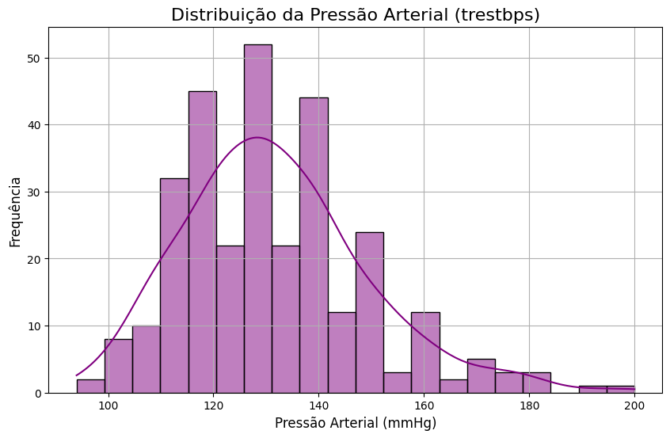

```python
# Estatísticas para a variável 'trestbps' (pressão arterial)
print(df_uci['trestbps'].describe())

# Gráfico de distribuição da pressão arterial (trestbps)
plt.figure(figsize=(10, 6))
sns.histplot(df_uci['trestbps'], kde=True, color='purple', bins=20)
plt.title('Distribuição da Pressão Arterial (trestbps)', fontsize=16)
plt.xlabel('Pressão Arterial (mmHg)', fontsize=12)
plt.ylabel('Frequência', fontsize=12)
plt.grid(True)
plt.show()
```

**Análise:** A média da pressão arterial é 131,7 mmHg, indicando que em geral, as pessoas no conjunto de dados têm pressão um pouco acima do normal (normalmente abaixo de 120 mmHg). A menor pressão registrada foi 94 mmHg e a maior foi 200 mmHg, mostrando que há casos com pressões extremas. A maioria das pessoas tem pressões arteriais entre 120 e 140 mmHg, com uma variação leve nos dados.

- **Estatísticas do colesterol (chol)**

```
count    303.000000
mean     246.693069
std       51.776918
min      126.000000
25%      211.000000
50%      241.000000
75%      275.000000
max      564.000000
Name: chol, dtype: float64
```

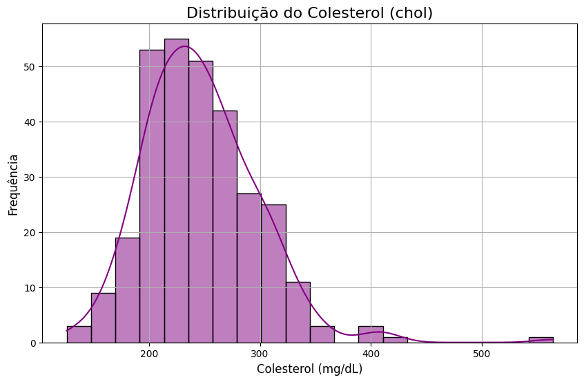

```python
# Estatísticas para a variável 'chol' (colesterol)
print(df_uci['chol'].describe())

# Gráfico de distribuição do colesterol (chol)
plt.figure(figsize=(10, 6))
sns.histplot(df_uci['chol'], kde=True, color='purple', bins=20)
plt.title('Distribuição do Colesterol (chol)', fontsize=16)
plt.xlabel('Colesterol (mg/dL)', fontsize=12)
plt.ylabel('Frequência', fontsize=12)
plt.grid(True)
plt.show()
```

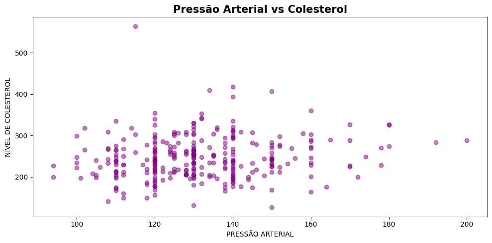

```python
# Exemplo de gráfico de dispersão entre 'trestbps' (pressão arterial) e 'chol' (colesterol)
fig, ax = plt.subplots(figsize=(10, 5))
ax.scatter(df_uci['trestbps'], df_uci['chol'], color='purple', alpha=0.5)
ax.set_title('Pressão Arterial vs Colesterol', fontsize=15, loc='center', weight='bold')
ax.set_xlabel('PRESSÃO ARTERIAL')
ax.set_ylabel('NÍVEL DE COLESTEROL')

plt.tight_layout()
plt.show()
```

### 3.2 Distribuição por condição cardíaca

Para simplificar, vamos converter a variável num em uma classificação binária (0 = "não há doença cardíaca", 1 = "há doença"), e gerar um gráfico para visualizarmos a quantidade de pacientes com e sem doença cardíaca.

```
Contagem de valores na variável alvo 'num':
num
0    164
1    139
Name: count, dtype: int64
```

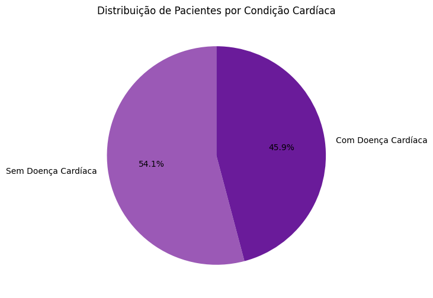

```python
# Convertendo valores maiores ou iguais a 1 em 1 para a variável 'num'
df_uci.loc[df_uci.num != 0, 'num'] = 1

# Contagem dos valores após a conversão
print("\nContagem de valores na variável alvo 'num':")
print(df_uci.num.value_counts())

# Contagem de pacientes com e sem doença cardíaca
condicao_cardio = df_uci.num.value_counts()

# Labels para o gráfico
labels = ['Sem Doença Cardíaca', 'Com Doença Cardíaca']

# Criação do gráfico de setores (pizza)
plt.figure(figsize=(6, 6))
plt.pie(condicao_cardio, labels=labels, autopct='%1.1f%%', startangle=90, colors=['#9b59b6', '#6a1b9a'])
plt.title('Distribuição de Pacientes por Condição Cardíaca')
plt.show()
```

**Análise:** Após a conversão, há 164 (54,1%) pacientes sem doença cardíaca e 139 (45,9%) com doença, sugerindo uma distribuição relativamente equilibrada entre os dois grupos.

### 3.3 Distribuição por sexo

A distribuição de pacientes por sexo é visualizada por meio de um gráfico de barras, ajudando a entender a composição de gênero no dataset.

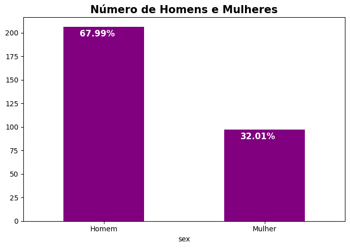

```python
# Visualização do número de homens e mulheres no dataset
fig, ax = plt.subplots(figsize=(7, 5))
ax = df_uci.sex.value_counts().plot(kind='bar', color='purple')
ax.set_title('Número de Homens e Mulheres', fontsize=15, loc='center', weight='bold')
ax.set_xticklabels(['Homem', 'Mulher'], rotation=0)

# Adicionando percentual de cada barra
total = df_uci.sex.value_counts().sum()
for p in ax.patches:
    percentage = f"{100 * p.get_height() / total:.2f}%"
    ax.annotate(percentage, (p.get_x() + 0.1, p.get_height() - 10), fontsize=12, color='white', weight='bold')

plt.tight_layout()
plt.show()
```

**Análise:** O gráfico revela que 67,99% dos pacientes são homens, enquanto 32,01% são mulheres. Isso pode indicar uma maior prevalência ou risco de doenças cardíacas entre os homens.

```python
# Estatísticas para a variável 'trestbps' (pressão arterial)
print(df_uci['trestbps'].describe())

# Estatísticas para a variável 'chol' (colesterol)
print(df_uci['chol'].describe())
```

```
count    303.000000
mean     131.689769
std       17.599748
min       94.000000
25%      120.000000
50%      130.000000
75%      140.000000
max      200.000000
Name: trestbps, dtype: float64
count    303.000000
mean     246.693069
std       51.776918
min      126.000000
25%      211.000000
50%      241.000000
75%      275.000000
max      564.000000
Name: chol, dtype: float64
```

### 3.4 Relação entre Idade e Colesterol

A relação entre idade e níveis de colesterol é analisada por meio de um gráfico de dispersão, revelando possíveis padrões entre essas variáveis.

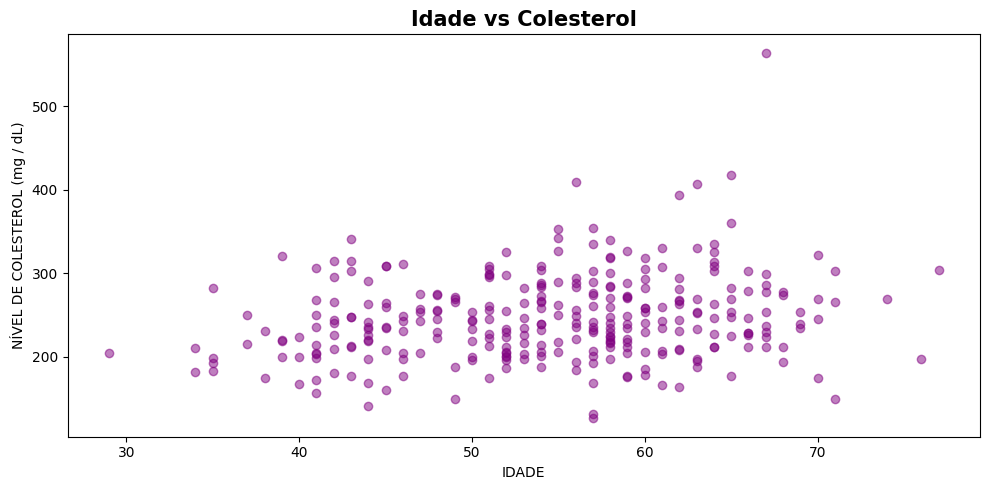

```python
# Relação entre idade e colesterol
fig, ax = plt.subplots(figsize=(10, 5))
ax.scatter(df_uci['age'], df_uci['chol'], color='purple', alpha=0.5)
ax.set_title('Idade vs Colesterol', fontsize=15, loc='center', weight='bold')
ax.set_xlabel('IDADE')
ax.set_ylabel('NÍVEL DE COLESTEROL (mg / dL)')

plt.tight_layout()
plt.show()
```

**Análise:** O gráfico mostra que à medida que a idade aumenta, os níveis de colesterol também tendem a aumentar, com um pico na faixa etária de 50 a 70 anos, o que pode sinalizar um grupo de risco para doenças cardíacas.

### 3.5 Análise de correlação

A matriz de correlação entre as variáveis é gerada para identificar relações entre os atributos que podem ser úteis para modelos de aprendizado de máquina.

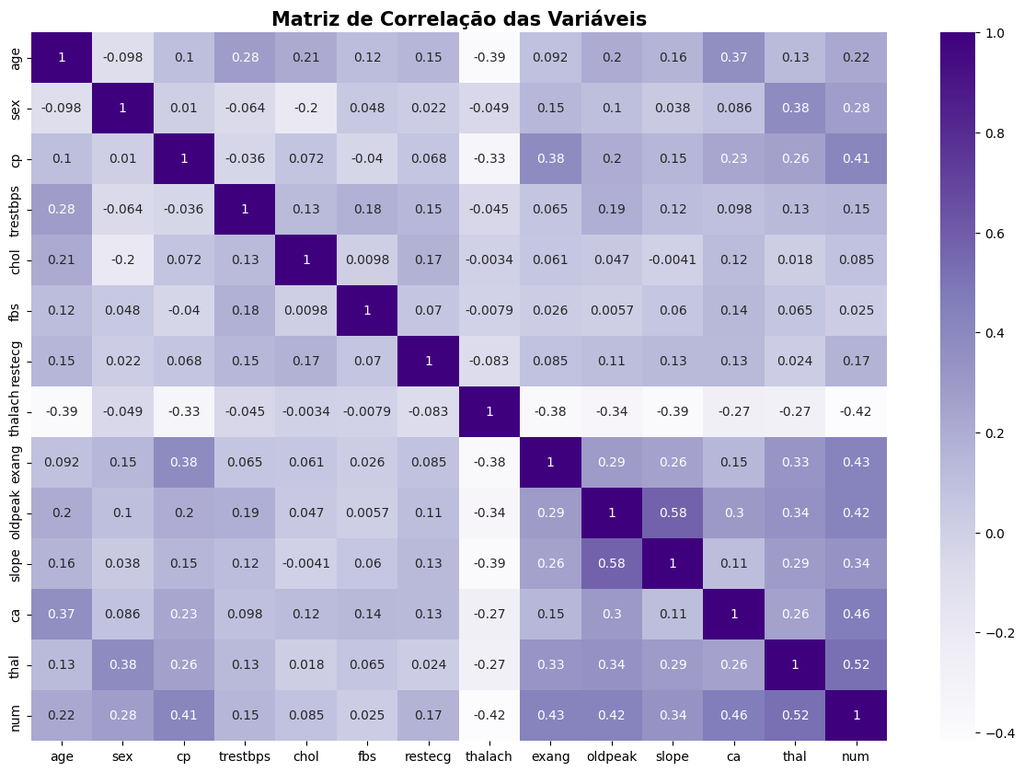

```python
# Matriz de correlação
fig, ax = plt.subplots(figsize=(15, 10))
sns.heatmap(df_uci.corr(), annot=True, cmap='Purples', fmt='.2g', ax=ax)
plt.title("Matriz de Correlação das Variáveis", fontsize=15, weight='bold')
plt.show()
```

### **4. Preparação dos dados**

Nesta etapa, vamos preparar os dados para os modelos de machine learning, convertendo as variáveis e normalizando os valores para análise mais eficiente. Após vamos treinar os modelos de **Random Forest** e **Regressão Logística** com os dados de treino, vamos comparar os resultados utilizando o classification report que apresenta as métricas de avaliação, como precisão, recall, f1-score e acurácia.

```python
# Separação das variáveis
X = df_uci.drop('num', axis=1)
y = df_uci['num']

# Padronização dos dados
X = StandardScaler().fit_transform(X)

# Divisão dos dados em treino e teste (80% treino, 20% teste)
X_train, X_test, y_train, y_test = train_test_split(X, y, test_size=0.28, random_state=42)
```

### 4.1 Treinamento e avaliação do modelo Random Forest

```python
# Treinamento do modelo Random Forest
RF_model = RandomForestClassifier(n_estimators=10, criterion='entropy', random_state=42)
RF_model.fit(X_train, y_train)

# Avaliação do modelo Random Forest
y_pred_rf = RF_model.predict(X_test)

# Verificando a acurácia do modelo Random Forest
print('[Acurácia] Random Forest:', accuracy_score(y_test, y_pred_rf))

# Exibindo o relatório de classificação detalhado para Random Forest
print('\n[Classification Report] Random Forest')
print(classification_report(y_test, y_pred_rf))
```

```
[Acurácia] Random Forest: 0.8

[Classification Report] Random Forest
              precision    recall  f1-score   support

           0       0.79      0.84      0.81        44
           1       0.82      0.76      0.78        41

    accuracy                           0.80        85
   macro avg       0.80      0.80      0.80        85
weighted avg       0.80      0.80      0.80        85
```

**Análise:** O modelo Random Forest apresentou:

- **Acurácia:** 80%
- **Precisão:** 79% (sem doença), 82% (com doença)
- **Recall:** 84% (sem doença), 76% (com doença)
- **F1-Score:** 81% (sem doença), 78% (com doença)

### 4.2 Treinamento e avaliação do modelo de Regressão Logística

```python
# Treinamento do modelo de Regressão Logística
log_reg = LogisticRegression(max_iter=200)
log_reg.fit(X_train, y_train)

# Avaliação do modelo de Regressão Logística
y_pred_log_reg = log_reg.predict(X_test)

# Verificando a acurácia do modelo de Regressão Logística
print('[Acurácia] Regressão Logística:', accuracy_score(y_test, y_pred_log_reg))

# Exibindo o relatório de classificação detalhado para Regressão Logística
print('\n[Classification Report] Regressão Logística')
print(classification_report(y_test, y_pred_log_reg))
```

```
[Acurácia] Regressão Logística: 0.8705882352941177

[Classification Report] Regressão Logística
              precision    recall  f1-score   support

           0       0.88      0.86      0.87        44
           1       0.86      0.88      0.87        41

    accuracy                           0.87        85
   macro avg       0.87      0.87      0.87        85
weighted avg       0.87      0.87      0.87        85
```

**Análise:** O modelo Regressão Logística apresentou:

- **Acurácia:** 87%
- **Precisão:** 88% (sem doença), 86% (com doença)
- **Recall:** 86% (sem doença), 88% (com doença)
- **F1-Score:** 87% (sem doença), 87% (com doença)

### 4.3 Comparação entre os Modelos

Após treinar os modelos de Random Forest e Regressão Logística, vamos comparar os resultados utilizando as métricas de precisão, recall, f1-score e acurácia.

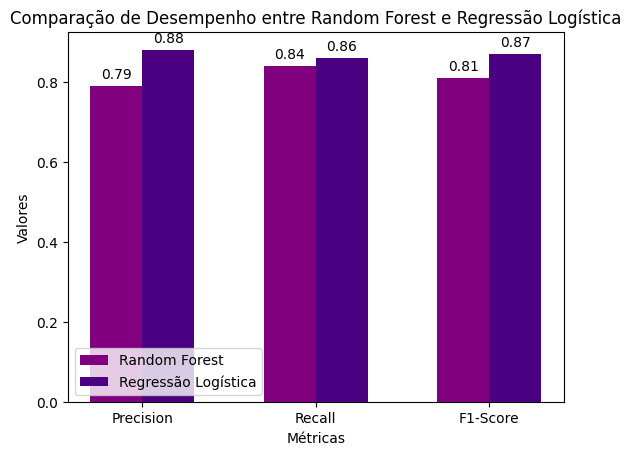

```python
# Definindo as métricas a serem comparadas
metrics = ['Precision', 'Recall', 'F1-Score']
rf_scores = [
    0.79,  # Precision para classe 0 (Random Forest)
    0.84,  # Recall para classe 0 (Random Forest)
    0.81   # F1-Score para classe 0 (Random Forest)
]
log_reg_scores = [
    0.88,  # Precision para classe 0 (Logistic Regression)
    0.86,  # Recall para classe 0 (Logistic Regression)
    0.87   # F1-Score para classe 0 (Logistic Regression)
]

# Criando o gráfico
x = np.arange(len(metrics))  # A posição das barras
width = 0.3  # Largura das barras

# Criando as barras
fig, ax = plt.subplots()
bars_rf = ax.bar(x - width/2, rf_scores, width, label='Random Forest', color='purple')  # Cor roxa para Random Forest
bars_log_reg = ax.bar(x + width/2, log_reg_scores, width, label='Regressão Logística', color='indigo')  # Cor roxa escuro para Logistic Regression

# Adicionando rótulos e título
ax.set_xlabel('Métricas')
ax.set_ylabel('Valores')
ax.set_title('Comparação de Desempenho entre Random Forest e Regressão Logística')
ax.set_xticks(x)
ax.set_xticklabels(metrics)
ax.legend()

# Exibindo os valores nas barras
def add_values(bars):
    for bar in bars:
        height = bar.get_height()
        ax.annotate(f'{height:.2f}',
                    xy=(bar.get_x() + bar.get_width() / 2, height),
                    xytext=(0, 3),  # Deslocamento para cima
                    textcoords="offset points",
                    ha='center', va='bottom')

# Adicionando os valores às barras
add_values(bars_rf)
add_values(bars_log_reg)

# Exibindo o gráfico
plt.show()
```

### 4.4 Análise da Matriz de Confusão

A matriz ajuda a ver com mais clareza como o modelo performa, detalhando quantos casos foram classificados corretamente e quantos foram classificados erroneamente.

```python
# Matriz de Confusão para o modelo Random Forest
rf_conf_matrix = confusion_matrix(y_test, y_pred_rf)
print(pd.DataFrame(rf_conf_matrix, index=['Real_Neg', 'Real_Pos'], columns=['Pred_Neg', 'Pred_Pos']))

# Matriz de Confusão para o modelo Regressão Logística
log_reg_conf_matrix = confusion_matrix(y_test, y_pred_log_reg)
print(pd.DataFrame(log_reg_conf_matrix, index=['Real_Neg', 'Real_Pos'], columns=['Pred_Neg', 'Pred_Pos']))
```

```
          Pred_Neg  Pred_Pos
Real_Neg        37         7
Real_Pos        10        31
          Pred_Neg  Pred_Pos
Real_Neg        38         6
Real_Pos         5        36
```

**Matriz de Confusão para o modelo Random Forest:** O modelo teve um bom desempenho, com muitas classificações corretas. No entanto, houve alguns erros, especialmente nas classes positivas, com falsos positivos e falsos negativos, o que é comum em modelos de aprendizado de máquina.

**Matriz de Confusão para o modelo Regressão Logística** O modelo mostrou um desempenho superior, com mais classificações corretas e menos erros nas previsões das classes positivas. Houve menos falsos positivos e negativos em comparação com o modelo Random Forest, indicando maior precisão.

## **Conclusão Final**

Na análise dos dados, observei que a variável alvo apresenta uma leve predominância de pacientes sem doença cardíaca (164 casos) em comparação aos pacientes com a doença (139 casos). Além disso, em relação à distribuição por sexo, a maior parte dos pacientes são homens (cerca de 68%), enquanto as mulheres representam cerca de um terço do grupo.

Quanto à idade e aos níveis de colesterol, percebi um padrão interessante: a partir dos 40 anos, os níveis de colesterol começam a subir, com um aumento mais acentuado a partir dos 50 anos. Isso destaca a importância de monitoramento regular da saúde, especialmente para homens na meia-idade, a fim de identificar e prevenir doenças cardíacas.

A preparação dos dados foi realizada com sucesso, com as variáveis devidamente padronizadas e prontas para serem utilizadas nos modelos de machine learning. Durante esse processo, apliquei os conhecimentos adquiridos nas disciplinas de Técnicas de Machine Learning e IA para Saúde, além de contar com o apoio do ChatGPT para traduzir dados, corrigir códigos e entender conceitos. Como estou em processo de aprendizado, esses recursos foram fundamentais para me ajudar a realizar essa análise com mais confiança e clareza.